# POLI 110: Confounding

November 27, 2025

## Correlation to Causation

## Solutions to Confounding

1. Recap
2. Before/After Assumptions
3. Beyond Before and After

## Recap

## Solutions to Confounding

**Every way** of using correlation as evidence for causality **makes assumptions**

- FPCI cannot be solved without assumptions
- With assumptions, can say confounding/bias is not a problem

| Solution | How Bias Solved | Which Bias Removed | Assumes | Internal Validity | External Validity |
| --- | --- | --- | --- | --- | --- |
| Experiment | Randomization Breaks \(W \rightarrow X\) link | **All** confounding variables | 1. \(X\) is random 2. Change only \(X\) | High | Low |
| Conditioning | Hold confounders constant | Only confounders conditioned on | 1. Condition on all confounders 2. Low measurement error 3. Cases similar in \(W\) | Low | High |

Yesterday

[video not shown]

Back in 2017…

[interactive chart not shown]

Did Trump’s rhetoric affect anti-Muslim hate crimes?

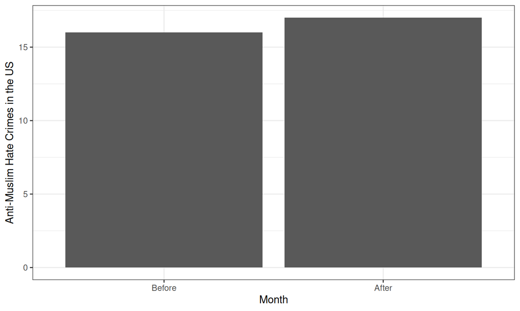

## Before and After

## Before and After

We can make Before and After comparisons: What is it?

**before and after**: examine the change in \(Y\) in a single case (or group of cases) where \(X\) changes over time (from before to after)

## Example: Before and After

Taking the same data from [Feinberg, Branton, and Martinez-Ebers](https://lmas.unt.edu/sites/lmas.unt.edu/files/lmas/Hate%20Incidents%20Spike_0.pdf)…

- we focus **only** on counties that **ever had** a Trump (Clinton) rally
- compare the month **after** the rally \((X = \text{Rally})\) to the month **before** the rally \((X = \text{No Rally})\)

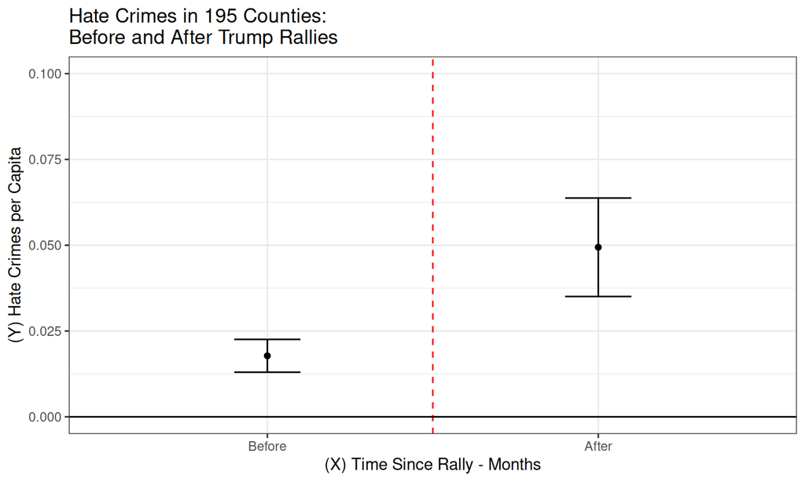

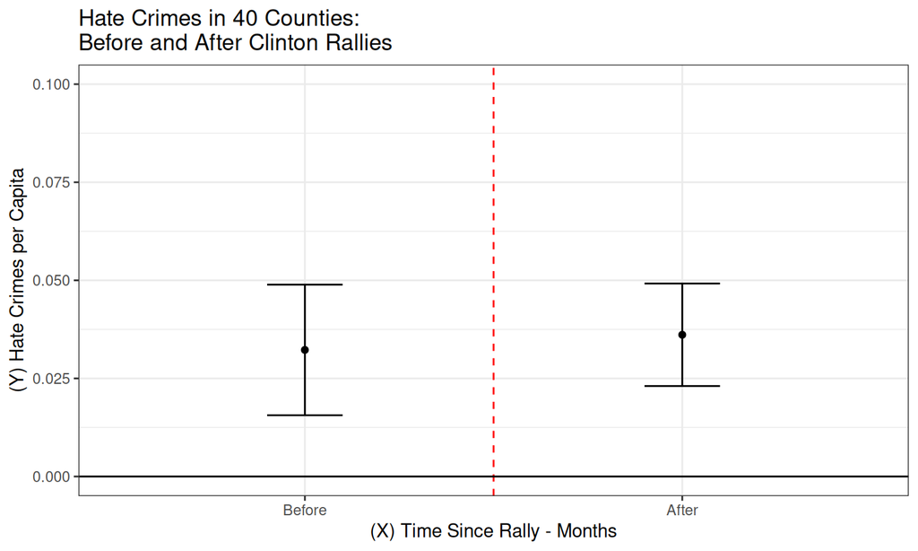

## Design Based Solutions

**Conditioning** removes confounding by:

- **identify** possible confounding variables
- **measure** confounding variables
- relationship b/t \(X\) and \(Y\) for cases with **similar value** of confounding variables \(W\).

## Design Based Solutions

**Design-based** solutions (like **Before and After**) remove confounding by:

- selecting cases for comparison in order to eliminate **many** known/unknown as well as measurable/unmeasurable confounding variables.
- the nature of the comparison holds constant **classes of confounding variables**, not **specific** confounding variables.
- by a “class” we mean all confounding variables that share certain properties

## Example: Before and After

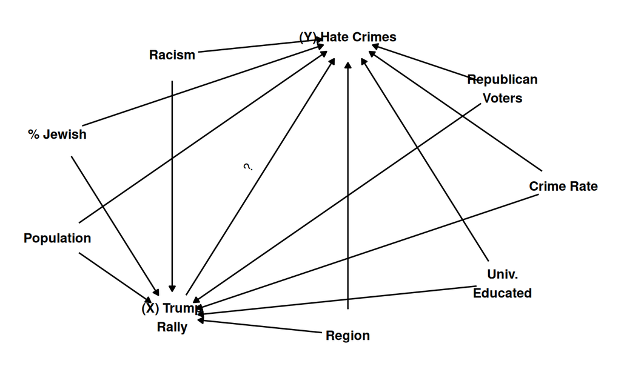

## Example: Before and After

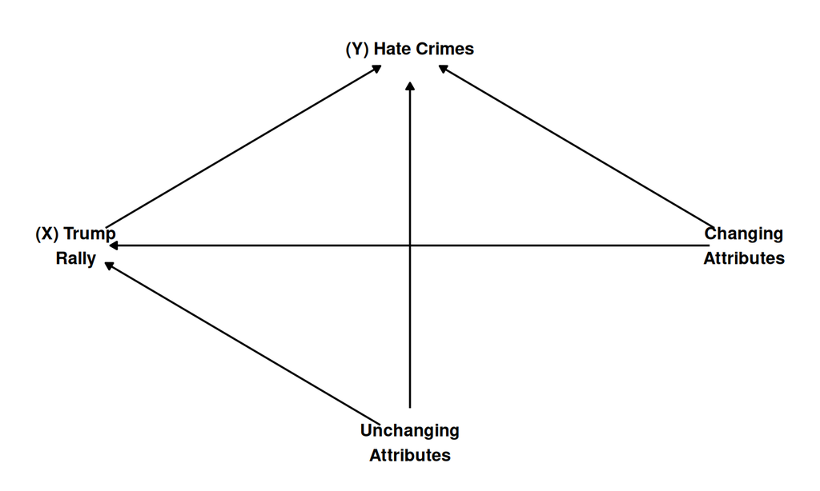

## Example: Before and After

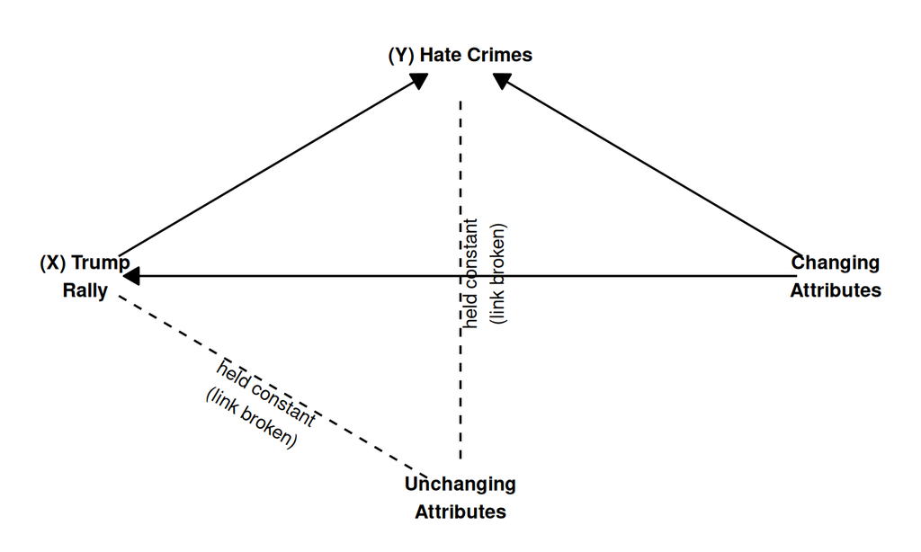

## Example: Before and After

### **How does it work?**…

**All** confounding variables (affect whether a rally occurs; affect hate crimes) that are **unchanging over time** (before to) are held constant.

- because held constant, cannot produce confounding
- e.g., demographic features, political leaning, location/geography, long-term economic trends, 8chan white nationalists
- any variable that **does not change *in the time period of the comparison*** (in this case, two months) held constant
- does not matter if we can think of or even measure the confounders

| Solution | How Bias Solved | Which Bias Removed | Assumes | Internal Validity | External Validity |
| --- | --- | --- | --- | --- | --- |
| Experiment | Randomization Breaks \(W \rightarrow X\) link | **All** confounding variables | 1. \(X\) is random 2. Change only \(X\) | High | Low |
| Conditioning | Hold confounders constant | Only confounders conditioned on | 1. Condition on all confounders 2. Low measurement error 3. Cases similar in \(W\) | Low | High |
| Before and After | Hold confounders constant | variables unchanging over time | ? | ? | ? |

## Before and After Assumptions…

## Design Based Solutions

Just like experiments and confounding, **Before and After** comparisons plug in for MISSING potential outcomes.

| County | Time | \(Y:\) HC(Yes) | \(Y:\) HC(No) | \(X:\) Rally |
| --- | --- | --- | --- | --- |
| \(c\) | Before | \(\color{red}{\text{Hate Crimes}_{c,Before}[\text{Rally}]}\) | \(\color{black}{\text{Hate Crimes}_{c,Before}[\text{No Rally}]}\) | No |
|  |  |  | \(\Downarrow\) |  |
| \(c\) | After | \(\color{black}{\text{Hate Crimes}_{c,After}[\text{Rally}]}\) | \(\color{red}{\text{Hate Crimes}_{c,After}[\text{No Rally}]}\) | Yes |

## Design Based Solutions

| County | Time | \(Y:\) HC(Yes) | \(Y:\) HC(No) | \(X:\) Rally |
| --- | --- | --- | --- | --- |
| \(c\) | Before | \(\color{red}{\text{Hate Crimes}_{c,Before}[\text{Rally}]}\) | \(\color{black}{\text{Hate Crimes}_{c,Before}[\text{No Rally}]}\) | No |
|  |  |  | \(\Downarrow\) |  |
| \(c\) | After | \(\color{black}{\text{Hate Crimes}_{c,After}[\text{Rally}]}\) | \(\boxed{\color{black}{\text{Hate Crimes}_{c,Before}[\text{No Rally}]}}\) | Yes |

We **assume** \(\color{red}{\text{Hate Crimes}_{c,After}[\text{No Rally}]} = \\ \color{black}{\text{Hate Crimes}_{c,Before}[\text{No Rally}]}\)

That is: if \(X\) had not changed, \(Y\) would not have changed.

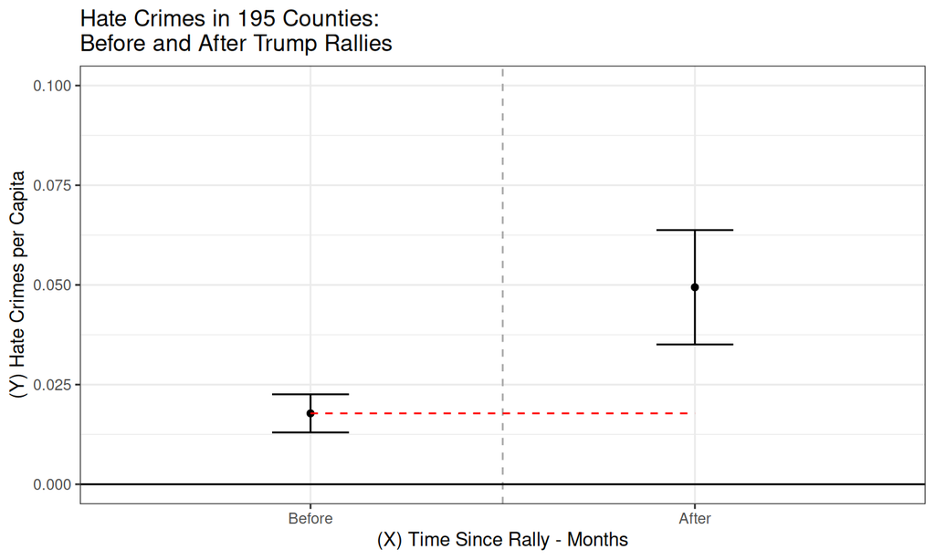

## Before and After

### External Validity

- We can examine “real world” causes of interest
- BUT… limited set of cases (only find effects of cases with change in \(X\) over time)

Not *quite* as widely applicable as confounding… \(\to\) Higher, but not Highest external validity

## Before and After

### Assumptions:

- assume that counterfactual potential outcomes of \(Y\) without \(X\) **after** \(X\) happens, same as factual \(Y\) without \(X\) **before** \(X\) happens
- equivalently: assume there are **no variables** \(W\) that affect \(Y\) and *change over time* with \(X\).

Any \(W\) that affects \(Y\) and changes with \(X\) will produce confounding **even if it does not *cause*** \(X\).

- this is a *new* source of confounding (result of our comparison)
- we **eliminate** confounding from **unchanging** variables, but open up possible **new** confounding from **changing** variables.

## Example: Before and After

Must assume there are **no variables** \(W\) that affect \(Y\) and *change over time* with \(X\).

### **Why might this assumption fail?**

- Did Trump rallies take place in places that are already **trending** toward having more hate crimes?
- Is it possible that Trump wanted to avoid controversy and waited to hold rallies in places until they had a month with a lower-than-usual number of hate crimes? (board)
- We can address these concerns by looking at longer-term trends…

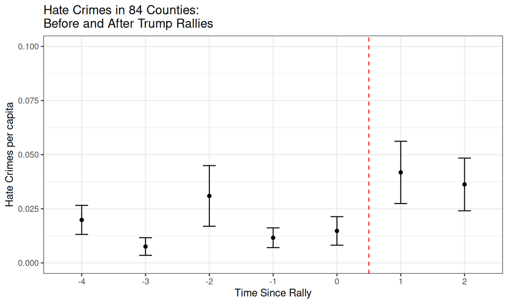

Mostly flat trend; change when rallies occur

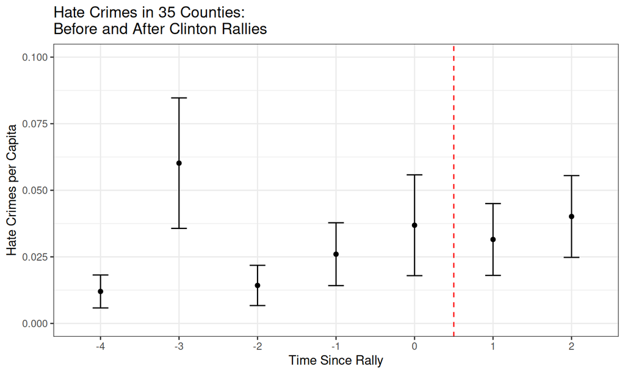

Mostly constant upward trend; no change when rallies occur

## Example: Before and After

### **When does this assumption fail?**

**Over-time comparison**, we can **create** confounding from variables that do not **cause** \(X\) to change, if they also **change with** \(X\) over time…

- Does rally change **measurement**, but not **actual number** of hate crimes? (Measurement bias)
- Are there are other changes over the same time-frame (change at the same time as \(X\), rallies)?
  - Less of a problem when comparing across very short time periods (fewer variables change)

Looking at the 2017 Truck attack: by **DAY**

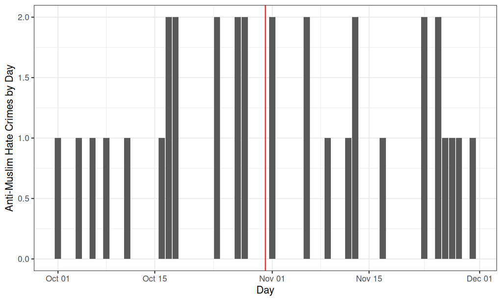

Looking at the 2017 Truck attack: by **MONTH**

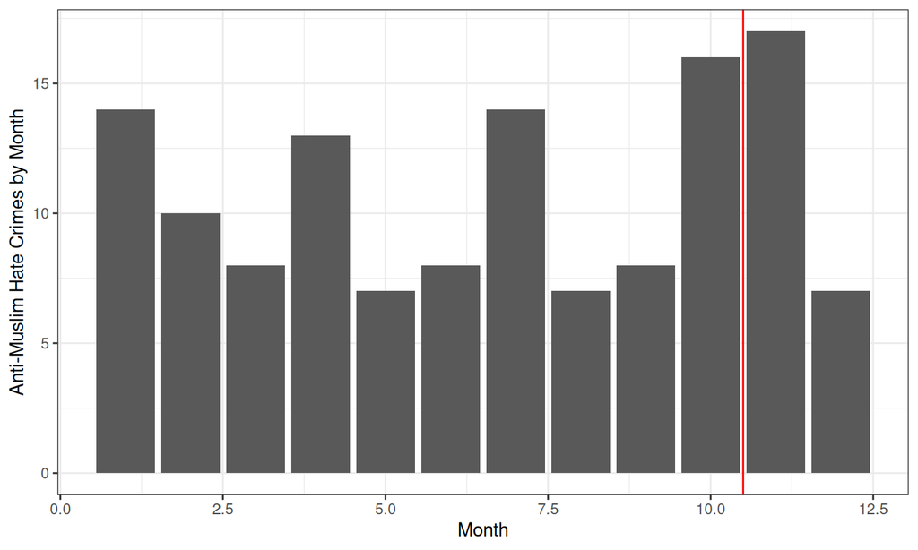

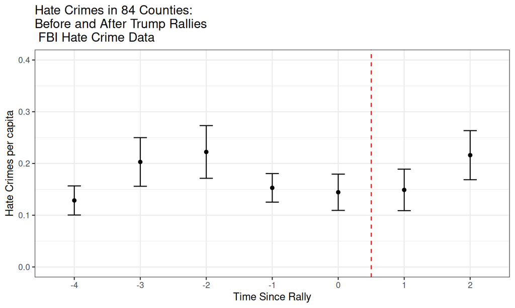

FBI data shows no change, compared to Anti-Defamation League \(\to\) “effect” is changing measurement of hate crimes?

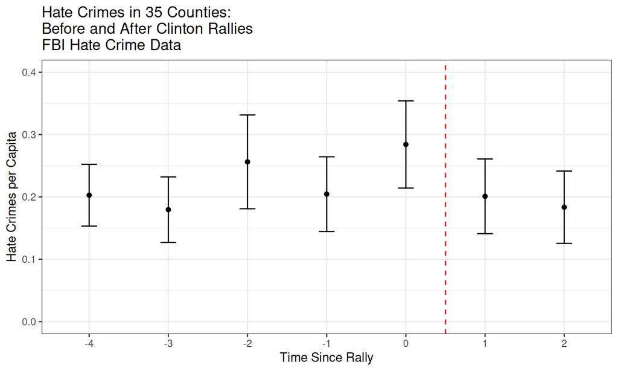

| Solution | How Bias Solved | Which Bias Removed | Assumes | Internal Validity | External Validity |
| --- | --- | --- | --- | --- | --- |
| Experiment | Randomization Breaks \(W \rightarrow X\) link | **All** confounding variables | 1. \(X\) is random 2. Change only \(X\) | High | Low |
| Conditioning | Hold confounders constant | Only confounders conditioned on | 1. Condition on all confounders 2. Low measurement error 3. Cases similar in \(W\) | Low | High |
| Before and After | Hold confounders constant | variables unchanging over time | No causes of \(Y\) change w/ \(X\) | Lower | Higher |

## Beyond Before and After

## Example: AI

[figure not shown]

## Example: Gun Laws

### **Does easing restrictions on gun laws increase murders committed using guns?**

- Some states in the US require all handgun purchasers to acquire a permit-to-purchase (PTP) license (LIKE CANADA).
- Only persons with a permit may purchase firearms
- In late 2007, Missouri eliminated its PTP requirement

## Example: Gun Laws

[Webster et al (2014)](https://link.springer.com/article/10.1007/s11524-014-9865-8) investigate:

- Did the removal of the PTP law **increase** firearms homicides in Missouri?
- Conditioning?: Lots of unique features of Missouri; no “otherwise similar” state.

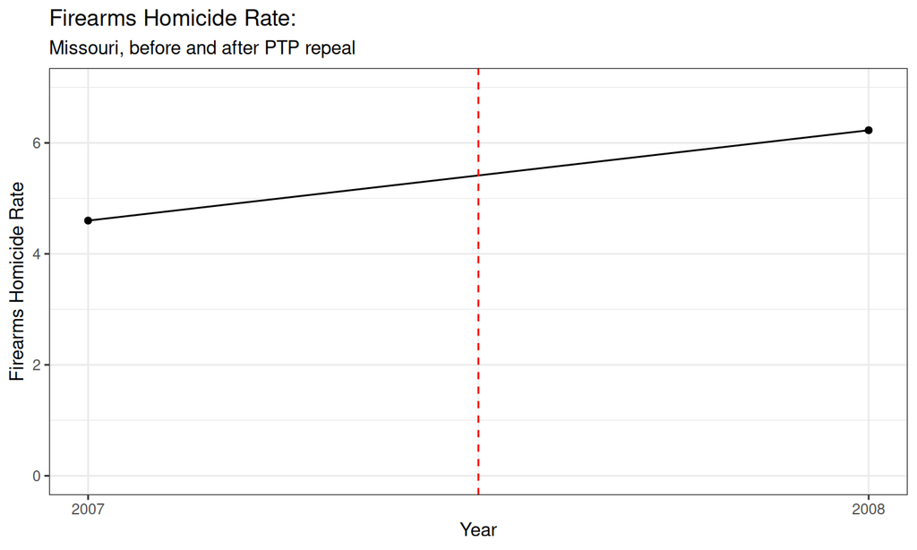

Did the repeal CAUSE a change in murders using guns?

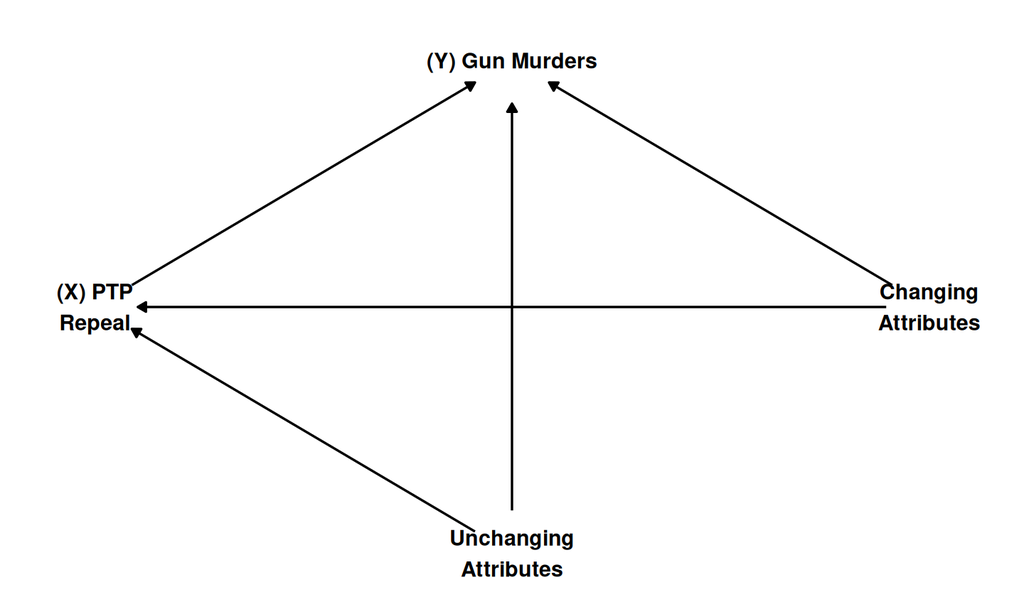

## Example: Gun Laws

Holds all unique, **unchanging** characteristics of Missouri constant…

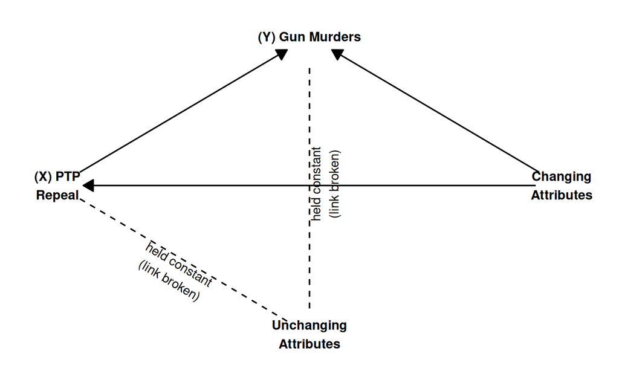

## Example: Gun Laws

But, we have to **assume** that there is nothing else about Missouri that

1. changed around the same time as the PTP (gun control) repeal
2. and affected Firearms Homicides

(or more technically, assume that \(\color{red}{\text{Murders}_{MO,After}[\text{No Repeal}]} = \color{black}{\text{Murders}_{MO,Before}[\text{No Repeal}]}\))

No long-term trends, no effects on measurement,

no changes in crimes \(\to\) PTP repeal

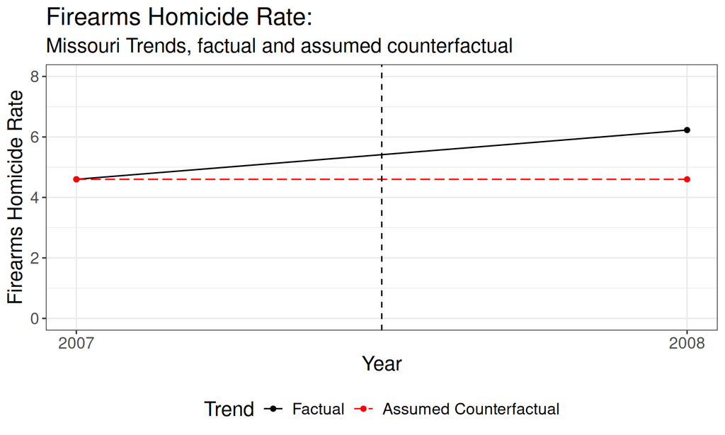

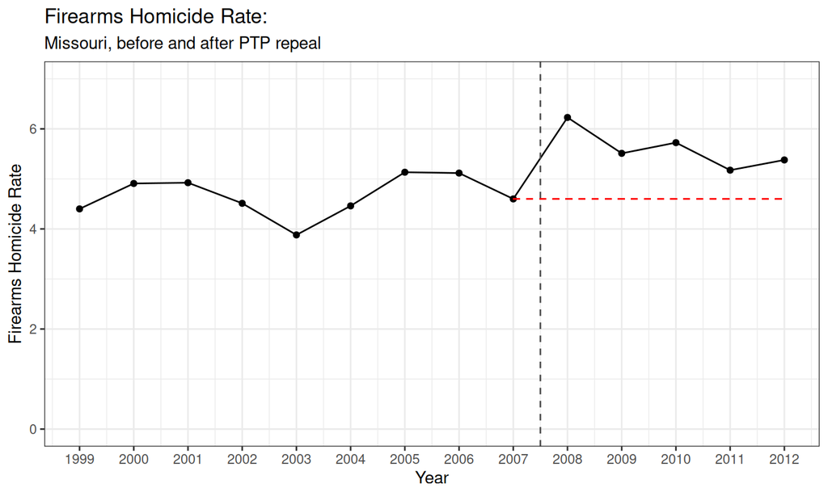

Does this plot make it easier/harder to believe PTP repeal caused more murders? (DISCUSS)

## Example: Gun Laws

Could be that **other things were changing between 2007-2008** that confound relationship between PTP and Murders?

- Maybe an upward trend in long term?
- Maybe 2006-2007 was aberration, 2008 a return to trend?
- Did anything else happen in 2008?

## Example: Gun Laws

| State | Time | Murder(Yes) | Murder(No) | Repeal |
| --- | --- | --- | --- | --- |
| Missouri | Before | \(\color{red}{\text{Murders}_{MO,Before}[\text{Repeal}]}\) | \(\color{black}{\text{Murders}_{MO,Before}[\text{No Repeal}]}\) | No |
|  |  |  | \(\neq\not\Downarrow\) |  |
| Missouri | After | \(\color{black}{\text{Murders}_{MO,After}[\text{Repeal}]}\) | \(\color{red}{\text{Murders}_{MO,After}[\text{No Repeal}]}\) | Yes |

It appears that \(\color{red}{\text{Murders}_{MO,After}[\text{No Repeal}]} \neq \\ \color{black}{\text{Murders}_{MO,Before}[\text{No Repeal}]}\)

Because other factors **changing murders**, regardless of repeal

## Example: Gun Laws

What can we do to remove confounding from other variables that **change over time**, like…

- weather patterns (hot weather \(\to\) murders)
- global financial crises/economic shocks
- political events
- Another way to put this question is: what would the trend in gun murders in Missouri have been **had there been no PTP repeal**? What was the **counterfactual trend**?

## Example: Gun Laws

We want to compare the **actual trend** in Missouri:

\(\begin{equation}\begin{split}\text{Trend}_{MO} ={} & \color{black}{\text{Murders}_{MO,After}[\text{Repeal}]} - \\ & \color{black}{\text{Murders}_{MO,Before}[\text{No Repeal}]}\end{split}\end{equation}\)

against the **counterfactual trend** in Missouri:

\(\begin{equation}\begin{split}\color{red}{\text{CF Trend}_{MO}} ={} & \color{red}{\text{Murders}_{MO,After}[\text{No Repeal}]} - \\ & \color{black}{\text{Murders}_{MO,Before}[\text{No Repeal}]}\end{split}\end{equation}\)

\(\small{\begin{equation}\begin{split} = {} & \overbrace{\{\text{Murders}_{MO,After}(\text{Repeal}) - \text{Murders}_{MO,Before}(\text{No Repeal})\}}^{\text{Missouri observed trend}} - \\ & \underbrace{\{\color{red}{\text{Murders}_{MO,After}(\text{No Repeal})} - \text{Murders}_{MO,Before}(\text{No Repeal})\}}_{\color{red}{\text{Missouri counterfactual trend}}}\end{split}\end{equation}}\)

- Before and After assumes the **counterfactual trend** is always 0

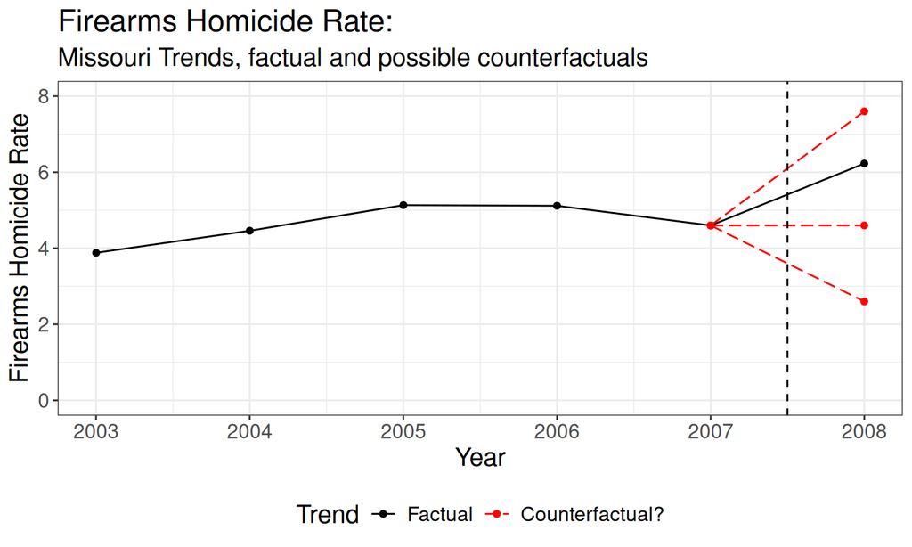

Many possible counterfactual trends…

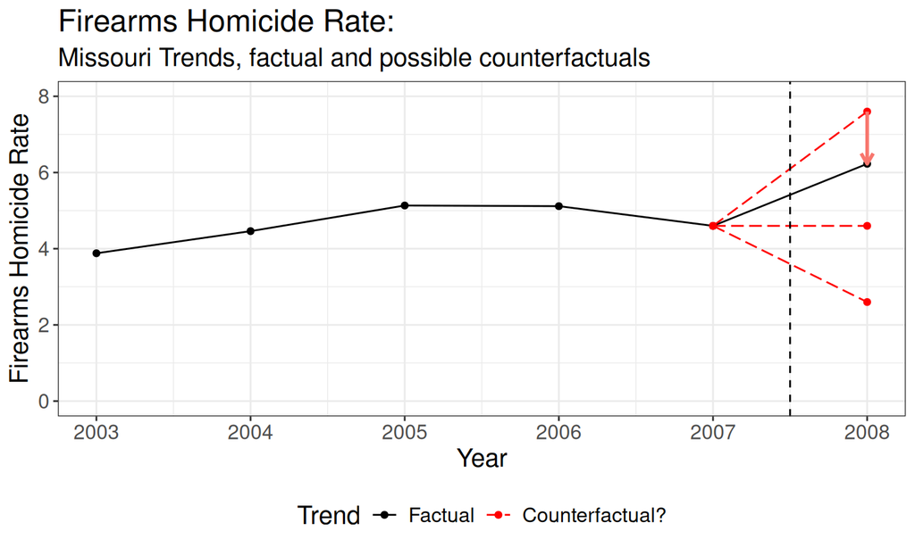

Which counterfactual is right?

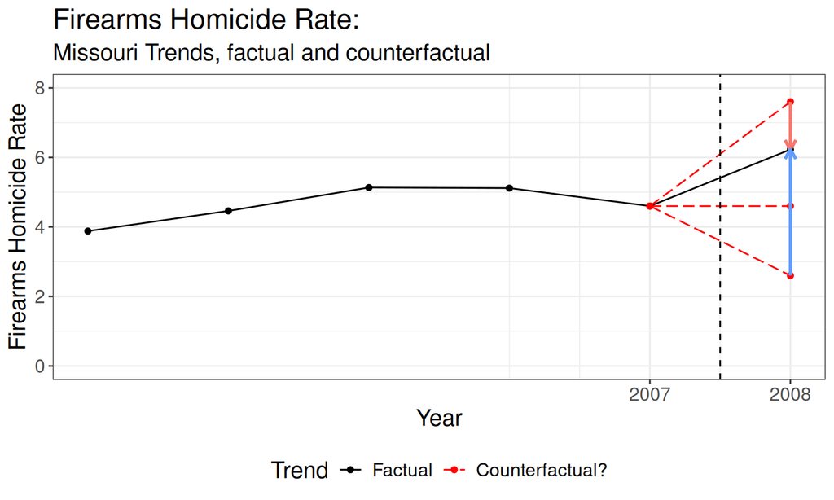

Which counterfactual is right?

## Example: Gun Laws

We can’t know the counterfactual trend in Missouri…

but we **can observe** the trends in **other states** that **did not change** their gun purchasing laws (no change in Gun Control, \(X\)).

- We can plug in the \(\text{factual TREND}\) in an “untreated” case (no change in \(X\)) for the \(\color{red}{\text{counterfactual TREND}}\) in the “treated” case (where \(X\) did change).

[figure not shown]

Arkansas has a different history that Missouri, so there are differences that are unchanging between them.

But, if Arkansas experiences same regional economic, political, cultural, weather trends as Missouri, they likely share the **same trends over time**.

Then, we can plug in

\(\small{\begin{equation}\begin{split} = {} & \overbrace{\{\text{Murders}_{MO,After}(\text{Repeal}) - \text{Murders}_{MO,Before}(\text{No Repeal})\}}^{\text{Missouri observed trend}} - \\ & \{\underbrace{\text{Murders}_{AR,After}(\text{No Repeal}) - \text{Murders}_{AR,Before}(\text{No Repeal})\}}_{\text{Arkansas observed trend}}\end{split}\end{equation}}\)

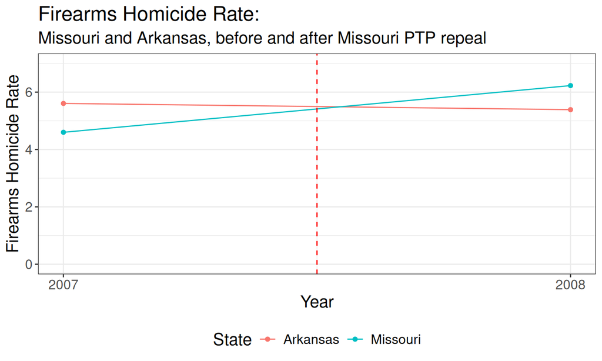

Missouri/Arkansas different in 2007, but if Missouri had same trend (counterfactually) as Arkansas, what would we expect Murders to have done in 2008 w/out the repeal?

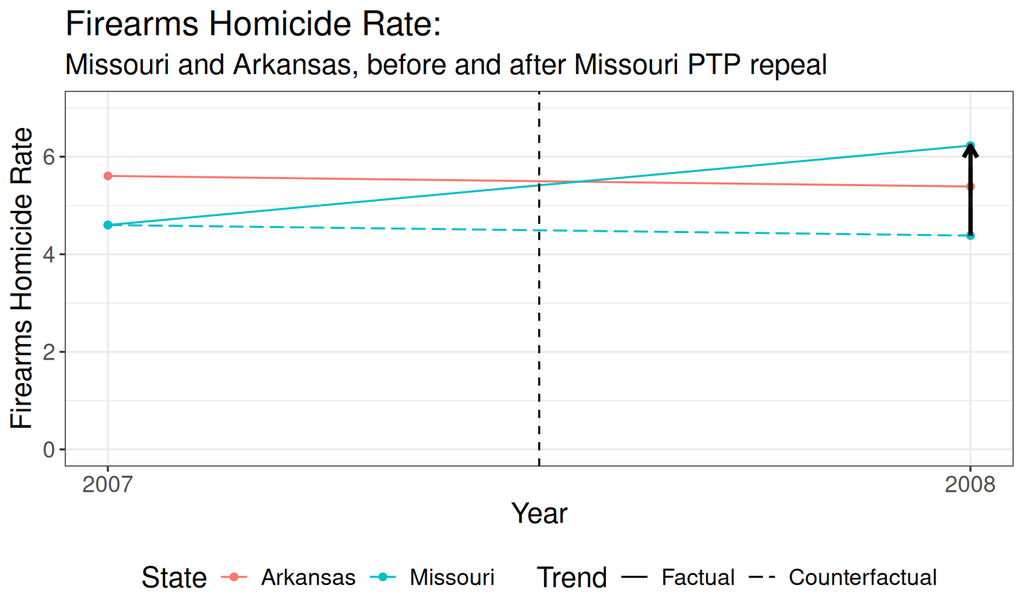

Missouri’s counterfactual trend is **parallel to** / same as Arkansas’s factual trend

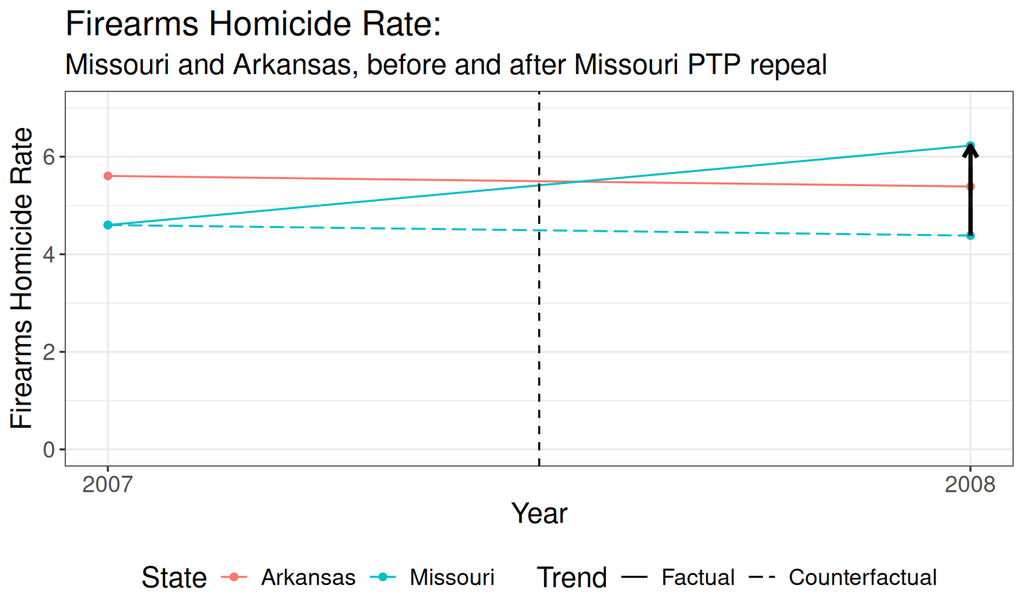

With your neighbors, discuss: Do you believe this is evidence of **causality**? What confounding does this address? What confounding does it not address?

## Difference in Differences

## Design Based Solution:

Like **before and after**, **difference in differences** comparisons are **design** based

- careful comparison rules out **groups** of confounding variables

## Design: Difference in Differences

**What is it?**

- Compare changes in “treated” cases before and after “treatment” to before and after changes in “untreated” cases

## Design: Difference in Differences

Why is it called **difference** in **differences**?

\(\small{\begin{equation}\begin{split} = {} & \overbrace{\{\text{Murders}_{MO,After}(\text{Repeal}) - \text{Murders}_{MO,Before}(\text{No Repeal})\}}^{\text{Missouri observed trend}} - \\ & \{\underbrace{\text{Murders}_{AR,After}(\text{No Repeal}) - \text{Murders}_{AR,Before}(\text{No Repeal})\}}_{\text{Arkansas observed trend}}\end{split}\end{equation}}\)

## Design: Difference in Difference

So:

- \(\mathrm{Difference \ 1} = Murders_{After} - Murders_{Before}\) gives us trend in murders in a \(State\)…
  - holding **unchanging attributes of state** constant (*difference over time*)
- \(\mathrm{Difference \ 2} = \mathrm{Difference \ 1}_{Missouri} - \mathrm{Difference \ 1}_{Arkansas}\) gives us change in murders in \(Treated\) over time, compared to trend in \(Control\)
  - holds **changing attributes of both states** constant (*difference in trends*)

## Design: Difference in Difference

|  | \(Murder_{Before}\) | \(Murder_{After}\) | **First Difference** |
| --- | --- | --- | --- |
| \(\mathrm{Missouri}\) | \(4.6\) | \(6.2\) | \(1.6\) |
| \(\mathrm{Arkansas}\) | \(5.6\) | \(5.4\) | \(-0.2\) |
| **Second Difference** |  |  | \(1.8\) |

## Design: Difference in Differences

**How does it work?**

- Hold constant **unchanging** attributes of cases (compare same case before and after “treatment”)
- Hold constant variables that **change together** over time in both “treated” and “untreated” cases

We don’t need to know/measure what these variables are!

## Design: Difference in Differences

### **Confounding Solved**…

All confounding variables (affect whether a PTP repealed; affect firearms homicides) that are **unchanging over time** are held constant

- comparing change over time with-in the same case

All confounding variables that **change the similarly** in “treated” and “untreated” case are held constant.

- By comparing change over time in “treated” to change over time in “control”

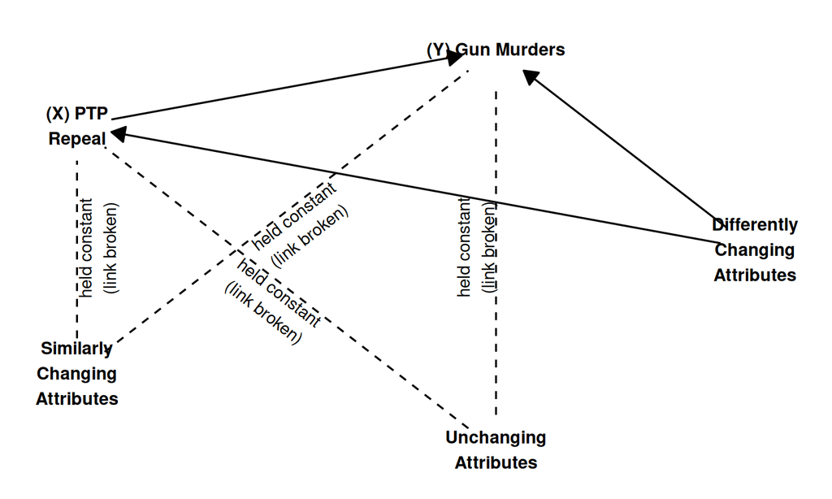

## Design: Difference in Differences

In order to infer \(X\) causes \(Y\) if \(X,Y\) correlated in difference-in-differences comparison…

### **Assumption**

- we assume the observed **trend** in \(Y\) for “untreated” case is **equal to** the “counterfactual trend” in \(Y\) for the “treated” case.
- Equivalently: we assume “treated” and “untreated” have the “parallel trends” in \(Y\), absent the change in \(X\).
- Equivalently: **no variables** that affect \(Y\) and **change over time differently** in “treated” and “untreated” cases

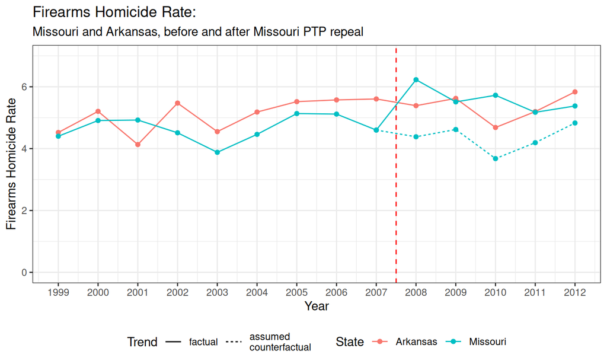

Do you believe assumption of “parallel trends”? (Counterfactual Missouri trend same as factual Arkansas trend)

## Design: Difference in Differences

### **Confounding UNSolved**…

- Arkansas and Missouri murder rates mostly move together before 2007.
- But large change in AR in 2001/2002 not in MO
- But in 2007, before law took effect, murders dipped

Perhaps there are some things that affect murder rates that change differently in these two states.

## Design: Difference in Differences

When is the assumption plausible?

- We can check to see if cases share trends **before** treatment, but does not prove they would have shared trends **after** treatment
- We should compare cases that experience many similar changes over time: comparing Missouri to British Columbia may not be helpful.

| Solution | How Bias Solved | Which Bias Removed | Assumes | Internal Validity | External Validity |
| --- | --- | --- | --- | --- | --- |
| Experiment | Randomization Breaks \(W \rightarrow X\) link | **All** confounding variables | 1. \(X\) is random 2. Change only \(X\) | Highest | Lowest |
| Conditioning | Hold confounders constant | Only variables conditioned on | see above | Lowest | Highest |
| Before and After | Hold confounders constant | variables unchanging over time | No causes of \(Y\) change w/ \(X\) | Lower | Higher |
| Diff in Diff | Hold confounders constant | unchanging and similarly changing | Parallel trends | Higher | Lower |